# Modeling Florida octocoral trends: Density data

Ronen Liberman

8-2-2024

*In this markdown file I am going to work with data that was prepared in a previous script. I am going to clean the data a little bit, then using model selection test for the most significant parameters that influence state of octocoral population in the last 11 years*

#Data prep. for modelling Here I filter the data so I can model density of Total population across years 2013 - 2023. The data was prepared in: “Creating_binding_all_datasets.R”

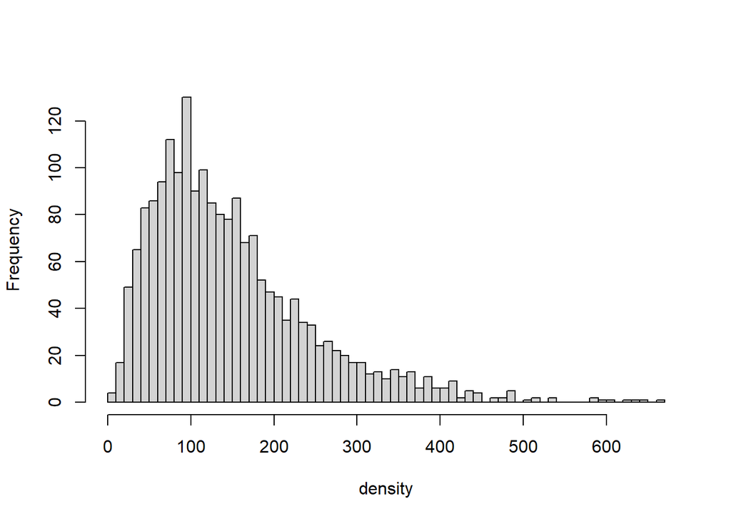

```
##  [1] "The Maze"              "White Shoal"           "Prolifera Patch"
##  [4] "Temptation Rock"       "Mayer's Peak"          "Bird Key Reef"
##  [7] "Black Coral Rock"      "Dade County 5"         "Broward County 4"
## [10] "Broward County 5"      "Broward County 6"      "Dade County 6"
## [13] "Dade County 7"         "Dade County 8"         "Palm Beach 2"
## [16] "Palm Beach 3"          "Broward County 1"      "Broward County 2"
## [19] "Broward County 3"      "Dade County 1"         "Dade County 2"
## [22] "Dade County 3"         "Palm Beach 4"          "Palm Beach 5"
## [25] "Dade County 4"         "Porter Patch"          "Admiral"
## [28] "West Turtle Shoal"     "Dustan Rocks"          "West Washer Women"
## [31] "Cliff Green"           "Carysfort Shallow"     "Alligator Shallow"
## [34] "Tennessee Shallow"     "Sombrero Shallow"      "Western Sambo Shallow"
## [37] "Sand Key Shallow"      "Carysfort Deep"        "Alligator Deep"
## [40] "Tennessee Deep"        "Sombrero Deep"         "Western Sambo Deep"
## [43] "Sand Key Deep"         "Molasses Shallow"      "Molasses Deep"
```

```
## [1] NPSDT _ P           NPSDT _ OD          FKNMS _ OD
## [4] SECREMP _ Inner     SECREMP _ Middle    SECREMP _ Outer
## [7] SECREMP _ Nearshore FKNMS _ P           FKNMS _ OS
## 9 Levels: FKNMS _ OD FKNMS _ OS FKNMS _ P NPSDT _ OD ... SECREMP _ Outer
```

Using different models I can examine the most significant factors affecting Total octocoral abundance. I am using count data and different explenatory varables. I am using a model selection method using the AIC parameter to select for the best model. Afterwards I am running a model validation functions on the best model.

Modeling using NBINOM2 dist.

```r
#check distribution
poisson_glmm_full_model_2013 = glmmTMB(counts ~ Year * Subregion +Depth+Habitat+(1|SiteID/StationID),
                          family = poisson,
                          data = Total.octo_no_2012)
```

```
## dropping columns from rank-deficient conditional model: HabitatP
```

```r
poisson_glmm_full_model_2013 <- update(poisson_glmm_full_model_2013, control = glmmTMBControl(optCtrl=list(iter.max=1e3,eval.max=1e3)))
```

```
## dropping columns from rank-deficient conditional model: HabitatP
```

```r
nbinom1_glmm_full_model_2013 = glmmTMB(counts ~ Year * Subregion +Depth+Habitat+(1|SiteID/StationID),
                          family = nbinom1,
                          data = Total.octo_no_2012)
```

```
## dropping columns from rank-deficient conditional model: HabitatP
```

```r
nbinom1_glmm_full_model_2013 <- update(nbinom1_glmm_full_model_2013, control = glmmTMBControl(optCtrl=list(iter.max=1e3,eval.max=1e3)))
```

```
## dropping columns from rank-deficient conditional model: HabitatP
```

```r
nbinom_glmm_full_model_2013 = glmmTMB(counts ~ Year * Subregion +Depth+Habitat+(1|SiteID/StationID),
                          family = nbinom2,
                          data = Total.octo_no_2012)
```

```
## dropping columns from rank-deficient conditional model: HabitatP
```

```r
nbinom_glmm_full_model_2013 <- update(nbinom_glmm_full_model_2013, control = glmmTMBControl(optCtrl=list(iter.max=1e3,eval.max=1e3)))
```

```
## dropping columns from rank-deficient conditional model: HabitatP
```

```r
AIC(poisson_glmm_full_model_2013, nbinom1_glmm_full_model_2013, nbinom_glmm_full_model_2013)
```

```
##                              df      AIC
## poisson_glmm_full_model_2013 85 27824.44
## nbinom1_glmm_full_model_2013 86 19703.91
## nbinom_glmm_full_model_2013  86 19480.36
```

```r
###nbinom2 best
```

```r
#nbinom_glmm_full_model <- update(nbinom_glmm_full_model, control = glmmTMBControl(optCtrl=list(iter.max=1e3,eval.max=1e3)))

nbinom_glmm_model_depthgroup_interaction_2013 <- glmmTMB(counts ~ Year * Depth+ (1|SiteID/StationID),
                      family = nbinom2,
                      data = Total.octo_no_2012)
#nbinom_glmm_model_depthgroup_interaction <- #update(nbinom_glmm_model_depthgroup_interaction, control = glmmTMBControl(optCtrl=list(iter.max=1e3,eval.max=1e3)))

nbinom_glmm_model_depthgroup_2013 <- glmmTMB(counts ~ Year * Depth_group + (1|SiteID/StationID),
                                 family = nbinom2,
                                 data = Total.octo_no_2012)
#nbinom_glmm_model_depthgroup <- update(nbinom_glmm_model_depthgroup, control = glmmTMBControl(optCtrl=list(iter.max=1e3,eval.max=1e3)))

nbinom_glmm_model_depth_2013 <- glmmTMB(counts ~ Year + Depth + (1|SiteID/StationID),
                                 family = nbinom2,
                                 data = Total.octo_no_2012)

nbinom_glmm_model_Subregion_2013 <- glmmTMB(counts ~ Year * Subregion+(1|SiteID/StationID),
                               family = nbinom2,
                                data = Total.octo_no_2012)

#nbinom_glmm_model_Subregion_2013 <- update(nbinom_glmm_model_Subregion_2013, control = glmmTMBControl(optCtrl=list(iter.max=1e3,eval.max=1e3)))

nbinom_glmm_model_Subregion2_2013 <- glmmTMB(counts ~ Year + Subregion+(1|SiteID/StationID),
                                 family = nbinom2,
                                 data = Total.octo_no_2012)
  #  nbinom_glmm_model_Subregion2 <- update(nbinom_glmm_model_Subregion2, control = glmmTMBControl(optCtrl=list(iter.max=1e3,eval.max=1e3)))

nbinom_glmm_model_Subregion3_2013 <- glmmTMB(counts ~ Year * Subregion+Depth + (1|SiteID/StationID),
                                 family = nbinom2,
                                 data = Total.octo_no_2012)
nbinom_glmm_model_Subregion3_2013 <- update(nbinom_glmm_model_Subregion3_2013, control = glmmTMBControl(optCtrl=list(iter.max=1e3,eval.max=1e3)))


nbionom_glmm_model_ProjectRegion_2013 <- glmmTMB(counts ~ Year * ProjectRegion+(1|SiteID/StationID),
                                 family = nbinom2,
                                 data = Total.octo_no_2012)
#nbionom_glmm_model_ProjectRegion <- update(nbionom_glmm_model_ProjectRegion, control = glmmTMBControl(optCtrl=list(iter.max=1e3,eval.max=1e3)))

nbinom_glmm_model_ProjectRegion2_2013 <- glmmTMB(counts ~ Year + ProjectRegion+(1|SiteID/StationID),
                                 family = nbinom2,
                                 data = Total.octo_no_2012)
#nbinom_glmm_model_ProjectRegion2 <- update(nbinom_glmm_model_ProjectRegion2, control = glmmTMBControl(optCtrl=list(iter.max=1e3,eval.max=1e3)))

nbinom_glmm_model_ProjectRegion3_2013 <- glmmTMB(counts ~ Year * ProjectRegion+Depth+(1|SiteID/StationID),
                                 family = nbinom2,
                                 data = Total.octo_no_2012)

nbinom_glmm_model_ProjectRegion4_2013 <- glmmTMB(counts ~ Year * ProjectRegion+Habitat+(1|SiteID/StationID),
                                 family = nbinom2,
                                 data = Total.octo_no_2012)
```

```
## dropping columns from rank-deficient conditional model: HabitatP
```

```r
nbinom_glmm_model_Year_2013 <- glmmTMB(counts ~ as.numeric(Year) + (1|SiteID/StationID),
                                 family = nbinom2,
                                 data = Total.octo_no_2012)
#nbinom_glmm_model_Year <- update(nbinom_glmm_model_Year, control = glmmTMBControl(optCtrl=list(iter.max=1e3,eval.max=1e3)))


nbinom_glmm_model_habitat_2013 <- glmmTMB(counts ~ Year * Habitat+(1|SiteID/StationID),
                                 family = nbinom2,
                                 data = Total.octo_no_2012)


nbinom_glmm_model_habitat2_2013 <- glmmTMB(counts ~ Year + Habitat+(1|SiteID/StationID),
                                 family = nbinom2,
                                 data = Total.octo_no_2012)

nbinom_glmm_model_habitat3_2013 <- glmmTMB(counts ~ Year + Habitat+Subregion+(1|SiteID/StationID),
                                 family = nbinom2,
                                 data = Total.octo_no_2012)
```

```
## dropping columns from rank-deficient conditional model: SubregionUK
```

```r
nbinom_glmm_model_null_2013 <- glmmTMB(counts ~  + 1,
                           family = nbinom2,
                            data = Total.octo_no_2012)

#add optional model that looks at habitat within region - this was where most variation was in our previous cover models

nbinom_glmm_model_reg.hab_2013 <- glmmTMB(counts ~ Year * Reg.Hab+(1|SiteID/StationID),
                                 family = nbinom2,
                                 data = Total.octo_no_2012)
```

```r
AICtab(nbinom_glmm_full_model_2013,
       nbinom_glmm_model_depthgroup_interaction_2013,nbinom_glmm_model_depthgroup_2013,
       nbinom_glmm_model_depth_2013,
    nbinom_glmm_model_Subregion_2013,nbinom_glmm_model_Subregion2_2013, nbinom_glmm_model_Subregion3_2013,
    nbionom_glmm_model_ProjectRegion_2013,nbinom_glmm_model_ProjectRegion2_2013,
    nbinom_glmm_model_ProjectRegion3_2013,nbinom_glmm_model_ProjectRegion4_2013,
    nbinom_glmm_model_Year_2013,
    nbinom_glmm_model_habitat_2013,nbinom_glmm_model_habitat2_2013,nbinom_glmm_model_habitat3_2013,
    nbinom_glmm_model_null_2013, nbinom_glmm_model_reg.hab_2013)
```

```
##                                               dAIC   df
## nbinom_glmm_model_reg.hab_2013                   0.0 102
## nbinom_glmm_model_habitat_2013                  17.8 80
## nbinom_glmm_model_Subregion_2013                48.9 80
## nbinom_glmm_model_Subregion3_2013               48.9 81
## nbinom_glmm_full_model_2013                     54.2 86
## nbionom_glmm_model_ProjectRegion_2013          121.7 36
## nbinom_glmm_model_ProjectRegion3_2013          121.8 37
## nbinom_glmm_model_ProjectRegion4_2013          123.7 41
## nbinom_glmm_model_depthgroup_interaction_2013  181.6 25
## nbinom_glmm_model_Subregion2_2013              181.9 20
## nbinom_glmm_model_ProjectRegion2_2013          184.6 16
## nbinom_glmm_model_depth_2013                   185.2 15
## nbinom_glmm_model_habitat3_2013                185.3 25
## nbinom_glmm_model_habitat2_2013                186.8 20
## nbinom_glmm_model_depthgroup_2013              198.4 47
## nbinom_glmm_model_Year_2013                    321.2 5
## nbinom_glmm_model_null_2013                   3369.3 2
```

**Summary of best model** The model that explains the variation of count data ~ Year * Region.Habitat is the FAVORITE.

[output not shown]

[output cut: 43 more lines]

[output not shown]

```
##  Family: nbinom2  ( log )
## Formula:          counts ~ Year * Reg.Hab + (1 | SiteID/StationID)
## Data: Total.octo_no_2012
##
##      AIC      BIC   logLik deviance df.resid
##  19426.2  19995.2  -9611.1  19222.2     1854
##
## Random effects:
##
## Conditional model:
##  Groups           Name        Variance Std.Dev.
##  StationID:SiteID (Intercept) 0.09872  0.3142
##  SiteID           (Intercept) 0.21929  0.4683
## Number of obs: 1956, groups:  StationID:SiteID, 179; SiteID, 45
##
## Dispersion parameter for nbinom2 family (): 23.4
##
## Conditional model:
##                                      Estimate Std. Error z value Pr(>|z|)
## (Intercept)                          4.996834   0.179868  27.781  < 2e-16 ***
## Year2014                            -0.020681   0.058608  -0.353 0.724182
## Year2015                            -0.001345   0.058539  -0.023 0.981665
## Year2016                            -0.078650   0.058714  -1.340 0.180396
## Year2017                            -0.022056   0.060110  -0.367 0.713666
## Year2018                            -0.259941   0.059076  -4.400 1.08e-05 ***
## Year2019                             0.039544   0.058470   0.676 0.498842
## Year2020                             0.097113   0.058462   1.661 0.096688 .
## Year2021                             0.140042   0.058420   2.397 0.016522 *
## Year2022                             0.119298   0.058492   2.040 0.041394 *
## Year2023                            -0.091498   0.058815  -1.556 0.119783
## Reg.HabFKNMS _ OS                   -0.154432   0.263552  -0.586 0.557898
## Reg.HabFKNMS _ P                    -0.240160   0.274293  -0.876 0.381269
## Reg.HabNPSDT _ OD                   -0.143813   0.537670  -0.267 0.789104
## Reg.HabNPSDT _ P                    -0.866906   0.291058  -2.978 0.002897 **
## Reg.HabSECREMP _ Inner              -1.021185   0.344790  -2.962 0.003059 **
## Reg.HabSECREMP _ Middle             -0.954928   0.311808  -3.063 0.002195 **
## Reg.HabSECREMP _ Nearshore          -0.353101   0.343630  -1.028 0.304157
## Reg.HabSECREMP _ Outer              -0.096958   0.253834  -0.382 0.702480
## Year2014:Reg.HabFKNMS _ OS          -0.040888   0.086938  -0.470 0.638131
## Year2015:Reg.HabFKNMS _ OS          -0.059480   0.086957  -0.684 0.493962
```

[output cut: 65 more lines]

```
## Year2021:Reg.HabSECREMP _ Nearshore  0.217272   0.109451   1.985 0.047132 *
## Year2022:Reg.HabSECREMP _ Nearshore  0.285382   0.109391   2.609 0.009085 **
## Year2023:Reg.HabSECREMP _ Nearshore  0.538922   0.109467   4.923 8.52e-07 ***
## Year2014:Reg.HabSECREMP _ Outer      0.112631   0.081055   1.390 0.164659
## Year2015:Reg.HabSECREMP _ Outer      0.196354   0.080870   2.428 0.015181 *
## Year2016:Reg.HabSECREMP _ Outer      0.353655   0.080937   4.369 1.25e-05 ***
## Year2017:Reg.HabSECREMP _ Outer      0.353226   0.081892   4.313 1.61e-05 ***
## Year2018:Reg.HabSECREMP _ Outer      0.401215   0.081398   4.929 8.26e-07 ***
## Year2019:Reg.HabSECREMP _ Outer      0.158091   0.080877   1.955 0.050619 .
## Year2020:Reg.HabSECREMP _ Outer      0.255269   0.080743   3.161 0.001570 **
## Year2021:Reg.HabSECREMP _ Outer      0.196485   0.080683   2.435 0.014881 *
## Year2022:Reg.HabSECREMP _ Outer      0.148938   0.080906   1.841 0.065641 .
## Year2023:Reg.HabSECREMP _ Outer      0.340736   0.081165   4.198 2.69e-05 ***
## ---
## Signif. codes:  0 '***' 0.001 '**' 0.01 '*' 0.05 '.' 0.1 ' ' 1
```

```
## # R2 for Mixed Models
##
##   Conditional R2: 0.897
##      Marginal R2: 0.234
```

Model validation

**Visualizing residuals** Plotting residuals vs. fitted shows more or less the same result.

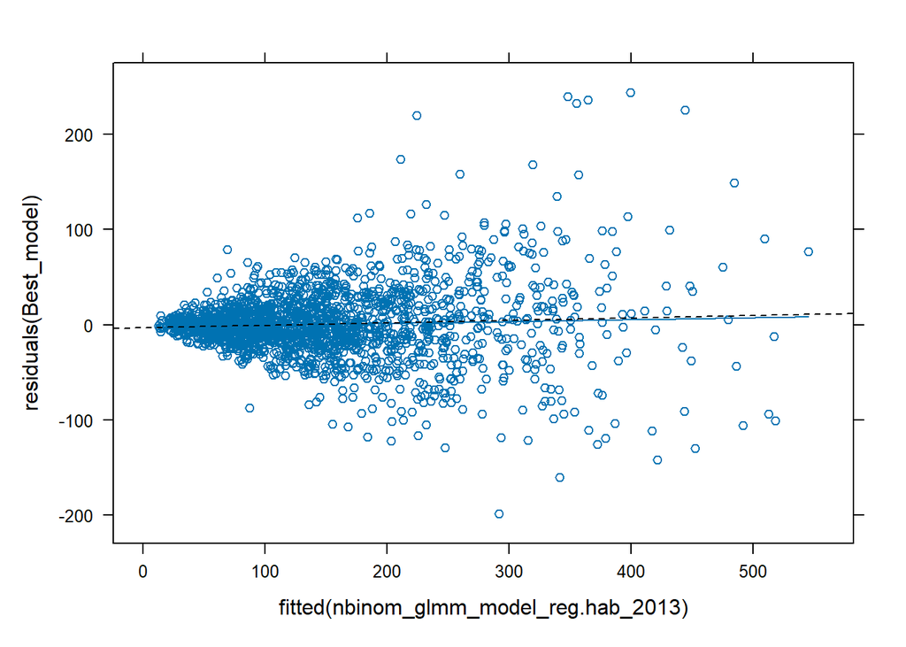

There is some high variation in the residuals - this probably creating the outliars and dispersion roblems inmymodels. lets try to reduce the outliars by removing some marginals locations.

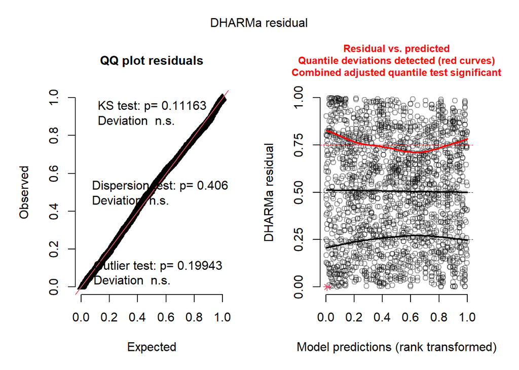

```r
simulationOutput <- simulateResiduals(Best_model, n = 1000, plot = TRUE,quantreg = T) #this looks pretty good, uniformity slightly off, but not too bad, some evidence of heterogeneity, recalculate residuals to check
```

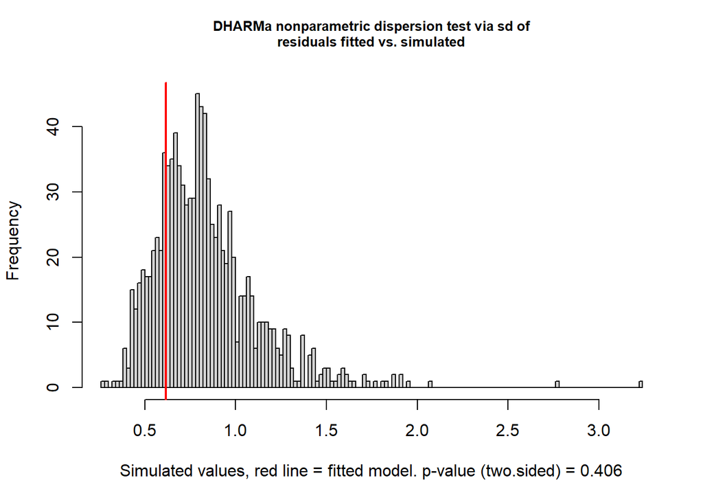

```
##
##  DHARMa nonparametric dispersion test via sd of residuals fitted vs.
##  simulated
##
## data:  simulationOutput
## dispersion = 0.73778, p-value = 0.406
## alternative hypothesis: two.sided
```

```r
testDispersion(simulationOutput) #dispersion fine
```

Validation per group - I examine individual groups in the dataset. #recalculating residuals , as I might have too many samples for Dharma to calculate, grouping by site, Year, or Subregion

```
## DHARMa:testOutliers with type = binomial may have inflated Type I error rates for integer-valued distributions. To get a more exact result, it is recommended to re-run testOutliers with type = 'bootstrap'. See ?testOutliers for details
```

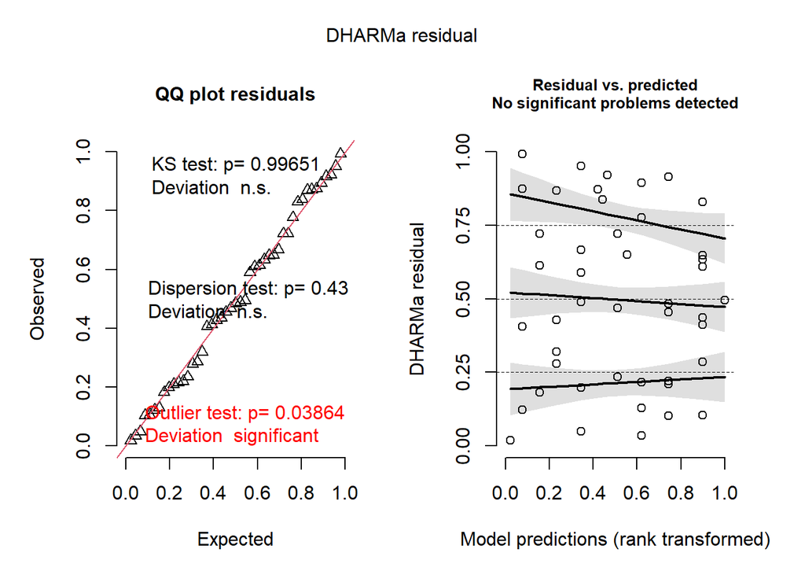

```r
resids.site <- recalculateResiduals(simulationOutput, group = Total.octo_no_2012$SiteID)
plot(resids.site) # heterogeneity good, uniformity improved, suggests an outlier
```

```
## DHARMa:testOutliers with type = binomial may have inflated Type I error rates for integer-valued distributions. To get a more exact result, it is recommended to re-run testOutliers with type = 'bootstrap'. See ?testOutliers for details
## DHARMa:testOutliers with type = binomial may have inflated Type I error rates for integer-valued distributions. To get a more exact result, it is recommended to re-run testOutliers with type = 'bootstrap'. See ?testOutliers for details
```

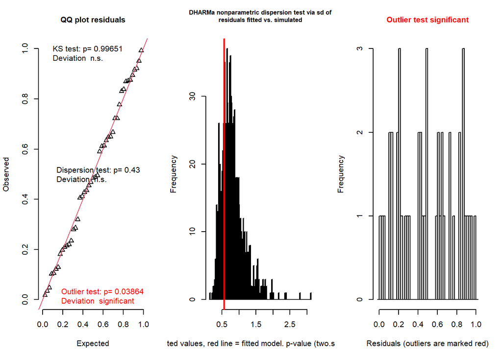

```
## $uniformity
##
##  Asymptotic one-sample Kolmogorov-Smirnov test
##
## data:  simulationOutput$scaledResiduals
## D = 0.060556, p-value = 0.9965
## alternative hypothesis: two-sided
##
##
## $dispersion
##
##  DHARMa nonparametric dispersion test via sd of residuals fitted vs.
##  simulated
##
## data:  simulationOutput
## dispersion = 0.69478, p-value = 0.43
## alternative hypothesis: two.sided
##
##
## $outliers
##
##  DHARMa outlier test based on exact binomial test with approximate
##  expectations
##
## data:  simulationOutput
## outliers at both margin(s) = 0, observations = 1956, p-value = 0.03864
## alternative hypothesis: true probability of success is not equal to 0.001998002
## 95 percent confidence interval:
##  0.000000000 0.001884153
## sample estimates:
## frequency of outliers (expected: 0.001998001998002 )
##                                                    0
```

```
## $uniformity
##
##  Asymptotic one-sample Kolmogorov-Smirnov test
##
## data:  simulationOutput$scaledResiduals
## D = 0.060556, p-value = 0.9965
## alternative hypothesis: two-sided
##
##
## $dispersion
##
##  DHARMa nonparametric dispersion test via sd of residuals fitted vs.
##  simulated
##
## data:  simulationOutput
## dispersion = 0.69478, p-value = 0.43
## alternative hypothesis: two.sided
##
##
## $outliers
##
##  DHARMa outlier test based on exact binomial test with approximate
##  expectations
##
## data:  simulationOutput
## outliers at both margin(s) = 0, observations = 1956, p-value = 0.03864
## alternative hypothesis: true probability of success is not equal to 0.001998002
## 95 percent confidence interval:
##  0.000000000 0.001884153
## sample estimates:
## frequency of outliers (expected: 0.001998001998002 )
##                                                    0
```

```r
testResiduals(resids.site) #residuals uniform, dispersion fine, evidence of outliers, try bootstrap as per Florian Hartig vignette advice
```

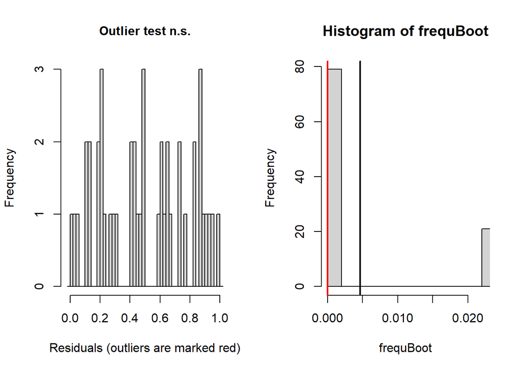

```
##
##  DHARMa bootstrapped outlier test
##
## data:  resids.site
## outliers at both margin(s) = 0, observations = 1956, p-value = 1
## alternative hypothesis: two.sided
##  percent confidence interval:
##  0.00000000 0.02222222
## sample estimates:
## outlier frequency (expected: 0.00466666666666667 )
##                                                  0
```

```r
testOutliers(resids.site, type = "bootstrap") #suggests after bootstrapping that residuals are fine
```

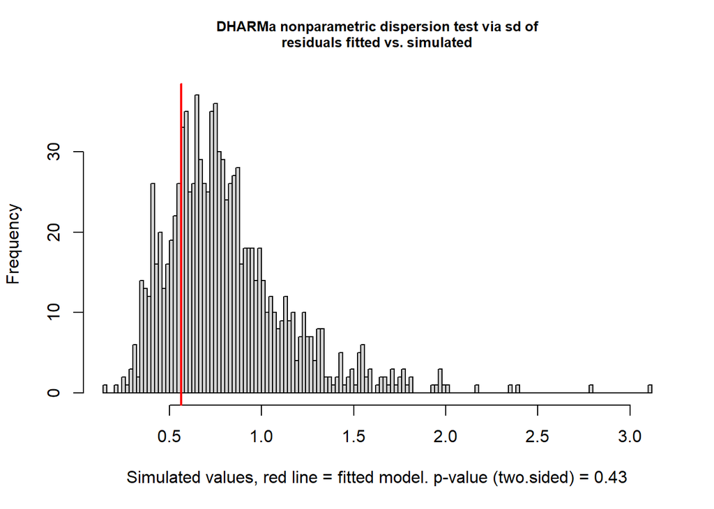

```
##
##  DHARMa nonparametric dispersion test via sd of residuals fitted vs.
##  simulated
##
## data:  simulationOutput
## dispersion = 0.69478, p-value = 0.43
## alternative hypothesis: two.sided
```

```r
testDispersion(resids.site) #dispersion fine
```

### Test for temporal autocorrelation

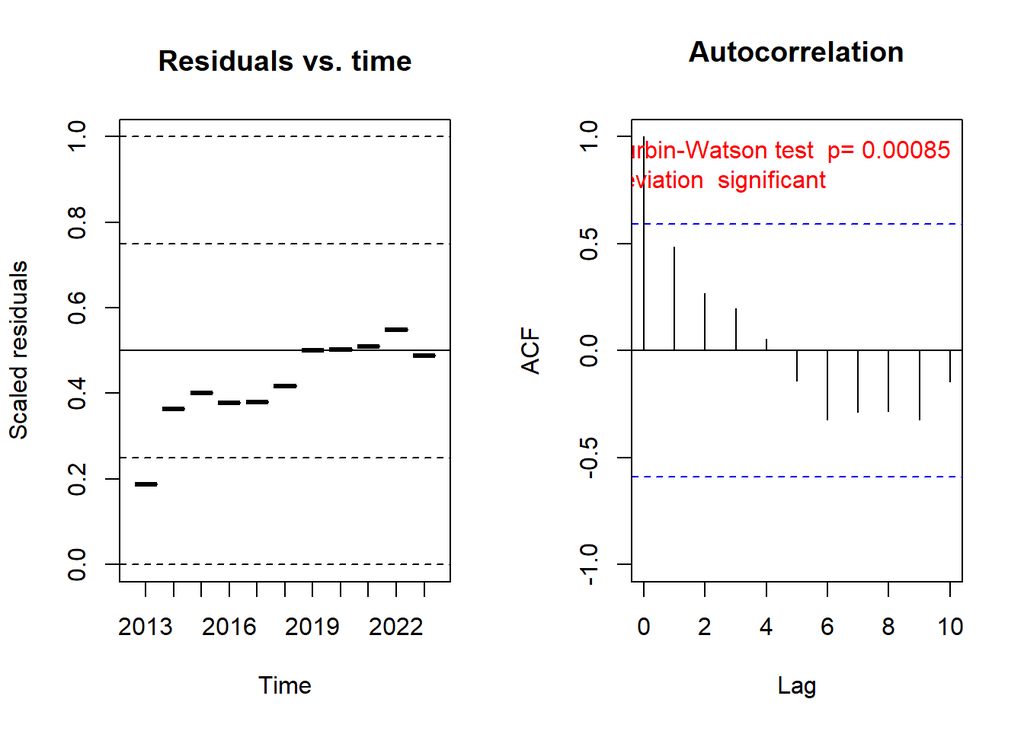

```
##
##  Durbin-Watson test
##
## data:  simulationOutput$scaledResiduals ~ 1
## DW = 0.44842, p-value = 0.0008547
## alternative hypothesis: true autocorrelation is not 0
```

```r
res <- recalculateResiduals(simulationOutput, group = Total.octo_no_2012$Year)
testTemporalAutocorrelation(simulationOutput = res, time = unique(Total.octo_no_2012$Year))
```

```r
#evidence of temporal autocorrelation (error term in year n is a function of the error in year n-1: suggest fitting an ar1 autocorrelation structure, this is present in the full residuals and the refitted residuals
```

### Include ar1 structure to account for temporal autocorrelation

```r
Best_model.ar1 <- glmmTMB(counts ~ Year * Reg.Hab+(1|SiteID/StationID) +
                            ar1(Year-1|StationID),
                                 family = nbinom2, data = Total.octo_no_2012)
Best_model.ar1 <- update(Best_model.ar1, control = glmmTMBControl(optCtrl=list(iter.max=1e3,eval.max=1e3)))

AIC(Best_model, Best_model.ar1) #improved AIC with ar1
```

```
##                 df      AIC
## Best_model     102 19426.19
## Best_model.ar1 104 18960.32
```

```r
summary(Best_model.ar1) #estimates ar1 correlation coefficient at 0.93 - this is very high - I suspect it's not actually needed given the random intercept specified and time being incorporated into the model, but after reading online and Zuur et al 2009 it is suggested to be incorporated when there is temporal autocorrelation. I'll check model estimates between the models with and without AR1 anyway
```

```
##  Family: nbinom2  ( log )
## Formula:
## counts ~ Year * Reg.Hab + (1 | SiteID/StationID) + ar1(Year -
##     1 | StationID)
## Data: Total.octo_no_2012
##
##      AIC      BIC   logLik deviance df.resid
##  18960.3  19540.5  -9376.2  18752.3     1852
##
## Random effects:
##
## Conditional model:
##  Groups           Name        Variance  Std.Dev.  Corr
##  StationID:SiteID (Intercept) 7.479e-08 0.0002735
##  SiteID           (Intercept) 2.025e-01 0.4500541
##  StationID        Year2013    1.387e-01 0.3724188 0.93 (ar1)
## Number of obs: 1956, groups:  StationID:SiteID, 179; SiteID, 45; StationID, 179
##
## Dispersion parameter for nbinom2 family (): 91.2
##
## Conditional model:
##                                     Estimate Std. Error z value Pr(>|z|)
## (Intercept)                          4.93968    0.17450  28.307  < 2e-16 ***
## Year2014                             0.01241    0.04426   0.280 0.779257
## Year2015                             0.04696    0.04994   0.940 0.346989
## Year2016                            -0.04814    0.05495  -0.876 0.380962
## Year2017                             0.01047    0.05996   0.175 0.861355
## Year2018                            -0.21664    0.06311  -3.433 0.000597 ***
## Year2019                             0.07375    0.06578   1.121 0.262185
## Year2020                             0.12039    0.06859   1.755 0.079213 .
## Year2021                             0.15810    0.07110   2.224 0.026177 *
## Year2022                             0.14025    0.07345   1.909 0.056199 .
## Year2023                            -0.07570    0.07589  -0.997 0.318525
## Reg.HabFKNMS _ OS                   -0.14216    0.25574  -0.556 0.578301
## Reg.HabFKNMS _ P                    -0.23296    0.26617  -0.875 0.381435
## Reg.HabNPSDT _ OD                   -0.08949    0.52198  -0.171 0.863883
## Reg.HabNPSDT _ P                    -0.81953    0.28266  -2.899 0.003739 **
## Reg.HabSECREMP _ Inner              -0.96958    0.33476  -2.896 0.003776 **
## Reg.HabSECREMP _ Middle             -0.95055    0.30273  -3.140 0.001690 **
## Reg.HabSECREMP _ Nearshore          -0.30948    0.33359  -0.928 0.353563
```

[output cut: 68 more lines]

```
## Year2021:Reg.HabSECREMP _ Nearshore  0.20215    0.13487   1.499 0.133908
## Year2022:Reg.HabSECREMP _ Nearshore  0.26994    0.13925   1.939 0.052550 .
## Year2023:Reg.HabSECREMP _ Nearshore  0.52743    0.14340   3.678 0.000235 ***
## Year2014:Reg.HabSECREMP _ Outer      0.08984    0.06090   1.475 0.140115
## Year2015:Reg.HabSECREMP _ Outer      0.16213    0.06906   2.348 0.018894 *
## Year2016:Reg.HabSECREMP _ Outer      0.33704    0.07608   4.430 9.43e-06 ***
## Year2017:Reg.HabSECREMP _ Outer      0.34009    0.08262   4.117 3.85e-05 ***
## Year2018:Reg.HabSECREMP _ Outer      0.37661    0.08769   4.295 1.75e-05 ***
## Year2019:Reg.HabSECREMP _ Outer      0.13919    0.09185   1.515 0.129647
## Year2020:Reg.HabSECREMP _ Outer      0.23652    0.09577   2.470 0.013529 *
## Year2021:Reg.HabSECREMP _ Outer      0.19901    0.09940   2.002 0.045267 *
## Year2022:Reg.HabSECREMP _ Outer      0.13491    0.10279   1.312 0.189360
## Year2023:Reg.HabSECREMP _ Outer      0.32634    0.10606   3.077 0.002091 **
## ---
## Signif. codes:  0 '***' 0.001 '**' 0.01 '*' 0.05 '.' 0.1 ' ' 1
```

```r
#Dharma tests residuals on the fixed effects so no need to re validate model, will check acf
#FYI ar1(Year-1) and ar1(Year+0) are equivalent and give the same estimates
```

#calculate r2, assess model estimates between ar1 adn no ar1 models

```r
#not possible to calculate r2 with the ar1 added so compute on fitted model
r2(Best_model) #conditional r2 = 0.897, marginal  = 0.234
```

```
## # R2 for Mixed Models
##
##   Conditional R2: 0.897
##      Marginal R2: 0.234
```

```r
summary(Best_model)
```

```
##  Family: nbinom2  ( log )
## Formula:          counts ~ Year * Reg.Hab + (1 | SiteID/StationID)
## Data: Total.octo_no_2012
##
##      AIC      BIC   logLik deviance df.resid
##  19426.2  19995.2  -9611.1  19222.2     1854
##
## Random effects:
##
## Conditional model:
##  Groups           Name        Variance Std.Dev.
##  StationID:SiteID (Intercept) 0.09872  0.3142
##  SiteID           (Intercept) 0.21929  0.4683
## Number of obs: 1956, groups:  StationID:SiteID, 179; SiteID, 45
##
## Dispersion parameter for nbinom2 family (): 23.4
##
## Conditional model:
##                                      Estimate Std. Error z value Pr(>|z|)
## (Intercept)                          4.996834   0.179868  27.781  < 2e-16 ***
## Year2014                            -0.020681   0.058608  -0.353 0.724182
## Year2015                            -0.001345   0.058539  -0.023 0.981665
## Year2016                            -0.078650   0.058714  -1.340 0.180396
## Year2017                            -0.022056   0.060110  -0.367 0.713666
## Year2018                            -0.259941   0.059076  -4.400 1.08e-05 ***
## Year2019                             0.039544   0.058470   0.676 0.498842
## Year2020                             0.097113   0.058462   1.661 0.096688 .
## Year2021                             0.140042   0.058420   2.397 0.016522 *
## Year2022                             0.119298   0.058492   2.040 0.041394 *
## Year2023                            -0.091498   0.058815  -1.556 0.119783
## Reg.HabFKNMS _ OS                   -0.154432   0.263552  -0.586 0.557898
## Reg.HabFKNMS _ P                    -0.240160   0.274293  -0.876 0.381269
## Reg.HabNPSDT _ OD                   -0.143813   0.537670  -0.267 0.789104
## Reg.HabNPSDT _ P                    -0.866906   0.291058  -2.978 0.002897 **
## Reg.HabSECREMP _ Inner              -1.021185   0.344790  -2.962 0.003059 **
## Reg.HabSECREMP _ Middle             -0.954928   0.311808  -3.063 0.002195 **
## Reg.HabSECREMP _ Nearshore          -0.353101   0.343630  -1.028 0.304157
## Reg.HabSECREMP _ Outer              -0.096958   0.253834  -0.382 0.702480
## Year2014:Reg.HabFKNMS _ OS          -0.040888   0.086938  -0.470 0.638131
## Year2015:Reg.HabFKNMS _ OS          -0.059480   0.086957  -0.684 0.493962
```

[output cut: 65 more lines]

```
## Year2021:Reg.HabSECREMP _ Nearshore  0.217272   0.109451   1.985 0.047132 *
## Year2022:Reg.HabSECREMP _ Nearshore  0.285382   0.109391   2.609 0.009085 **
## Year2023:Reg.HabSECREMP _ Nearshore  0.538922   0.109467   4.923 8.52e-07 ***
## Year2014:Reg.HabSECREMP _ Outer      0.112631   0.081055   1.390 0.164659
## Year2015:Reg.HabSECREMP _ Outer      0.196354   0.080870   2.428 0.015181 *
## Year2016:Reg.HabSECREMP _ Outer      0.353655   0.080937   4.369 1.25e-05 ***
## Year2017:Reg.HabSECREMP _ Outer      0.353226   0.081892   4.313 1.61e-05 ***
## Year2018:Reg.HabSECREMP _ Outer      0.401215   0.081398   4.929 8.26e-07 ***
## Year2019:Reg.HabSECREMP _ Outer      0.158091   0.080877   1.955 0.050619 .
## Year2020:Reg.HabSECREMP _ Outer      0.255269   0.080743   3.161 0.001570 **
## Year2021:Reg.HabSECREMP _ Outer      0.196485   0.080683   2.435 0.014881 *
## Year2022:Reg.HabSECREMP _ Outer      0.148938   0.080906   1.841 0.065641 .
## Year2023:Reg.HabSECREMP _ Outer      0.340736   0.081165   4.198 2.69e-05 ***
## ---
## Signif. codes:  0 '***' 0.001 '**' 0.01 '*' 0.05 '.' 0.1 ' ' 1
```

```r
summary(Best_model.ar1)
```

```
##  Family: nbinom2  ( log )
## Formula:
## counts ~ Year * Reg.Hab + (1 | SiteID/StationID) + ar1(Year -
##     1 | StationID)
## Data: Total.octo_no_2012
##
##      AIC      BIC   logLik deviance df.resid
##  18960.3  19540.5  -9376.2  18752.3     1852
##
## Random effects:
##
## Conditional model:
##  Groups           Name        Variance  Std.Dev.  Corr
##  StationID:SiteID (Intercept) 7.479e-08 0.0002735
##  SiteID           (Intercept) 2.025e-01 0.4500541
##  StationID        Year2013    1.387e-01 0.3724188 0.93 (ar1)
## Number of obs: 1956, groups:  StationID:SiteID, 179; SiteID, 45; StationID, 179
##
## Dispersion parameter for nbinom2 family (): 91.2
##
## Conditional model:
##                                     Estimate Std. Error z value Pr(>|z|)
## (Intercept)                          4.93968    0.17450  28.307  < 2e-16 ***
## Year2014                             0.01241    0.04426   0.280 0.779257
## Year2015                             0.04696    0.04994   0.940 0.346989
## Year2016                            -0.04814    0.05495  -0.876 0.380962
## Year2017                             0.01047    0.05996   0.175 0.861355
## Year2018                            -0.21664    0.06311  -3.433 0.000597 ***
## Year2019                             0.07375    0.06578   1.121 0.262185
## Year2020                             0.12039    0.06859   1.755 0.079213 .
## Year2021                             0.15810    0.07110   2.224 0.026177 *
## Year2022                             0.14025    0.07345   1.909 0.056199 .
## Year2023                            -0.07570    0.07589  -0.997 0.318525
## Reg.HabFKNMS _ OS                   -0.14216    0.25574  -0.556 0.578301
## Reg.HabFKNMS _ P                    -0.23296    0.26617  -0.875 0.381435
## Reg.HabNPSDT _ OD                   -0.08949    0.52198  -0.171 0.863883
## Reg.HabNPSDT _ P                    -0.81953    0.28266  -2.899 0.003739 **
## Reg.HabSECREMP _ Inner              -0.96958    0.33476  -2.896 0.003776 **
## Reg.HabSECREMP _ Middle             -0.95055    0.30273  -3.140 0.001690 **
## Reg.HabSECREMP _ Nearshore          -0.30948    0.33359  -0.928 0.353563
```

[output cut: 68 more lines]

```
## Year2021:Reg.HabSECREMP _ Nearshore  0.20215    0.13487   1.499 0.133908
## Year2022:Reg.HabSECREMP _ Nearshore  0.26994    0.13925   1.939 0.052550 .
## Year2023:Reg.HabSECREMP _ Nearshore  0.52743    0.14340   3.678 0.000235 ***
## Year2014:Reg.HabSECREMP _ Outer      0.08984    0.06090   1.475 0.140115
## Year2015:Reg.HabSECREMP _ Outer      0.16213    0.06906   2.348 0.018894 *
## Year2016:Reg.HabSECREMP _ Outer      0.33704    0.07608   4.430 9.43e-06 ***
## Year2017:Reg.HabSECREMP _ Outer      0.34009    0.08262   4.117 3.85e-05 ***
## Year2018:Reg.HabSECREMP _ Outer      0.37661    0.08769   4.295 1.75e-05 ***
## Year2019:Reg.HabSECREMP _ Outer      0.13919    0.09185   1.515 0.129647
## Year2020:Reg.HabSECREMP _ Outer      0.23652    0.09577   2.470 0.013529 *
## Year2021:Reg.HabSECREMP _ Outer      0.19901    0.09940   2.002 0.045267 *
## Year2022:Reg.HabSECREMP _ Outer      0.13491    0.10279   1.312 0.189360
## Year2023:Reg.HabSECREMP _ Outer      0.32634    0.10606   3.077 0.002091 **
## ---
## Signif. codes:  0 '***' 0.001 '**' 0.01 '*' 0.05 '.' 0.1 ' ' 1
```

```r
#summaries look pretty similar - best_model.ar1 has very low variance accounted for by station intercept but that's likely because it's accounted for in the ar1 temporal autocorrelation structure
```

### Post hoc analysis of fitted factors - fyi I haven’t looked at the raw data. Worth doing to make sure these estimates and comparisons make sense

```r
#calculated estimated marginal means and outputs estimates on the log scale

emm.year.hab <- emmeans(Best_model.ar1, ~ Year|Reg.Hab) #compares years within habitat
pairs(emm.year.hab) #significant positive ratio estimate means octo abundance in year x is greater than in year y, significant negative means sig decline between year x and year y
```

```
## Reg.Hab = FKNMS _ OD:
##  contrast             estimate     SE  df z.ratio p.value
##  Year2013 - Year2014 -0.012405 0.0443 Inf  -0.280  1.0000
##  Year2013 - Year2015 -0.046964 0.0499 Inf  -0.940  0.9975
##  Year2013 - Year2016  0.048145 0.0550 Inf   0.876  0.9986
##  Year2013 - Year2017 -0.010472 0.0600 Inf  -0.175  1.0000
##  Year2013 - Year2018  0.216642 0.0631 Inf   3.433  0.0252
##  Year2013 - Year2019 -0.073753 0.0658 Inf  -1.121  0.9896
##  Year2013 - Year2020 -0.120385 0.0686 Inf  -1.755  0.8064
##  Year2013 - Year2021 -0.158103 0.0711 Inf  -2.224  0.4878
##  Year2013 - Year2022 -0.140254 0.0735 Inf  -1.909  0.7113
##  Year2013 - Year2023  0.075700 0.0759 Inf   0.997  0.9959
##  Year2014 - Year2015 -0.034558 0.0414 Inf  -0.834  0.9991
##  Year2014 - Year2016  0.060550 0.0478 Inf   1.266  0.9743
##  Year2014 - Year2017  0.001934 0.0538 Inf   0.036  1.0000
##  Year2014 - Year2018  0.229047 0.0576 Inf   3.977  0.0034
##  Year2014 - Year2019 -0.061347 0.0608 Inf  -1.010  0.9955
##  Year2014 - Year2020 -0.107980 0.0640 Inf  -1.687  0.8426
##  Year2014 - Year2021 -0.145698 0.0669 Inf  -2.178  0.5204
##  Year2014 - Year2022 -0.127848 0.0695 Inf  -1.838  0.7572
##  Year2014 - Year2023  0.088106 0.0723 Inf   1.219  0.9805
##  Year2015 - Year2016  0.095108 0.0416 Inf   2.284  0.4446
##  Year2015 - Year2017  0.036492 0.0488 Inf   0.748  0.9997
##  Year2015 - Year2018  0.263606 0.0533 Inf   4.949  <.0001
##  Year2015 - Year2019 -0.026789 0.0570 Inf  -0.470  1.0000
##  Year2015 - Year2020 -0.073422 0.0606 Inf  -1.211  0.9815
##  Year2015 - Year2021 -0.111139 0.0639 Inf  -1.739  0.8153
##  Year2015 - Year2022 -0.093290 0.0669 Inf  -1.395  0.9500
##  Year2015 - Year2023  0.122664 0.0699 Inf   1.755  0.8063
##  Year2016 - Year2017 -0.058617 0.0431 Inf  -1.359  0.9581
##  Year2016 - Year2018  0.168497 0.0485 Inf   3.474  0.0219
##  Year2016 - Year2019 -0.121897 0.0528 Inf  -2.307  0.4292
##  Year2016 - Year2020 -0.168530 0.0571 Inf  -2.952  0.1072
##  Year2016 - Year2021 -0.206248 0.0608 Inf  -3.393  0.0288
##  Year2016 - Year2022 -0.188398 0.0641 Inf  -2.938  0.1111
##  Year2016 - Year2023  0.027556 0.0674 Inf   0.409  1.0000
##  Year2017 - Year2018  0.227114 0.0437 Inf   5.201  <.0001
##  Year2017 - Year2019 -0.063281 0.0489 Inf  -1.295  0.9699
##  Year2017 - Year2020 -0.109913 0.0538 Inf  -2.045  0.6172
##  Year2017 - Year2021 -0.147631 0.0579 Inf  -2.548  0.2764
```

[output cut: 469 more lines]

```
##  Year2018 - Year2022 -0.115191 0.0565 Inf  -2.037  0.6224
##  Year2018 - Year2023 -0.090666 0.0604 Inf  -1.502  0.9197
##  Year2019 - Year2020 -0.143955 0.0406 Inf  -3.545  0.0172
##  Year2019 - Year2021 -0.144167 0.0468 Inf  -3.078  0.0757
##  Year2019 - Year2022 -0.062216 0.0521 Inf  -1.194  0.9833
##  Year2019 - Year2023 -0.037692 0.0565 Inf  -0.667  0.9999
##  Year2020 - Year2021 -0.000212 0.0403 Inf  -0.005  1.0000
##  Year2020 - Year2022  0.081739 0.0467 Inf   1.750  0.8095
##  Year2020 - Year2023  0.106264 0.0519 Inf   2.046  0.6160
##  Year2021 - Year2022  0.081951 0.0404 Inf   2.027  0.6302
##  Year2021 - Year2023  0.106476 0.0468 Inf   2.277  0.4496
##  Year2022 - Year2023  0.024525 0.0407 Inf   0.603  1.0000
##
## Results are given on the log (not the response) scale.
## P value adjustment: tukey method for comparing a family of 11 estimates
```

```r
contrast(emm.year.hab) #compares estimate for the year against the mean for that habitat
```

```
## Reg.Hab = FKNMS _ OD:
##  contrast         estimate     SE  df z.ratio p.value
##  Year2013 effect -0.020168 0.0468 Inf  -0.431  0.8148
##  Year2014 effect -0.007763 0.0408 Inf  -0.190  0.8492
##  Year2015 effect  0.026796 0.0374 Inf   0.717  0.6506
##  Year2016 effect -0.068313 0.0350 Inf  -1.951  0.0936
##  Year2017 effect -0.009696 0.0346 Inf  -0.280  0.8492
##  Year2018 effect -0.236810 0.0334 Inf  -7.090  <.0001
##  Year2019 effect  0.053585 0.0331 Inf   1.617  0.1663
##  Year2020 effect  0.100217 0.0347 Inf   2.888  0.0107
##  Year2021 effect  0.137935 0.0372 Inf   3.704  0.0012
##  Year2022 effect  0.120086 0.0407 Inf   2.952  0.0107
##  Year2023 effect -0.095868 0.0452 Inf  -2.122  0.0745
##
## Reg.Hab = FKNMS _ OS:
##  contrast         estimate     SE  df z.ratio p.value
##  Year2013 effect -0.107968 0.0513 Inf  -2.103  0.0390
##  Year2014 effect -0.138964 0.0445 Inf  -3.125  0.0022
##  Year2015 effect -0.134785 0.0409 Inf  -3.297  0.0013
##  Year2016 effect -0.185433 0.0383 Inf  -4.840  <.0001
##  Year2017 effect -0.128242 0.0376 Inf  -3.409  0.0010
##  Year2018 effect -0.430691 0.0370 Inf -11.631  <.0001
##  Year2019 effect  0.037669 0.0359 Inf   1.051  0.2935
##  Year2020 effect  0.284095 0.0370 Inf   7.678  <.0001
##  Year2021 effect  0.282091 0.0398 Inf   7.082  <.0001
##  Year2022 effect  0.333995 0.0434 Inf   7.693  <.0001
##  Year2023 effect  0.188234 0.0481 Inf   3.913  0.0002
##
## Reg.Hab = FKNMS _ P:
##  contrast         estimate     SE  df z.ratio p.value
##  Year2013 effect -0.102691 0.0525 Inf  -1.956  0.1289
##  Year2014 effect  0.089536 0.0473 Inf   1.891  0.1289
##  Year2015 effect  0.085033 0.0435 Inf   1.956  0.1289
##  Year2016 effect  0.066485 0.0406 Inf   1.638  0.1858
##  Year2017 effect  0.081335 0.0387 Inf   2.104  0.1289
##  Year2018 effect -0.047228 0.0385 Inf  -1.226  0.3026
##  Year2019 effect  0.029264 0.0389 Inf   0.753  0.4516
##  Year2020 effect  0.035496 0.0407 Inf   0.871  0.4220
##  Year2021 effect -0.047072 0.0440 Inf  -1.070  0.3477
##  Year2022 effect -0.058782 0.0479 Inf  -1.228  0.3026
```

[output cut: 73 more lines]

```
##  contrast         estimate     SE  df z.ratio p.value
##  Year2013 effect -0.233049 0.0450 Inf  -5.179  <.0001
##  Year2014 effect -0.130801 0.0407 Inf  -3.211  0.0029
##  Year2015 effect -0.023951 0.0371 Inf  -0.646  0.5934
##  Year2016 effect  0.055842 0.0343 Inf   1.629  0.1622
##  Year2017 effect  0.117517 0.0324 Inf   3.623  0.0011
##  Year2018 effect -0.073077 0.0323 Inf  -2.262  0.0435
##  Year2019 effect -0.020102 0.0328 Inf  -0.614  0.5934
##  Year2020 effect  0.123853 0.0341 Inf   3.627  0.0011
##  Year2021 effect  0.124065 0.0368 Inf   3.374  0.0020
##  Year2022 effect  0.042114 0.0403 Inf   1.044  0.4075
##  Year2023 effect  0.017589 0.0444 Inf   0.396  0.6922
##
## Results are given on the log (not the response) scale.
## P value adjustment: fdr method for 11 tests
```

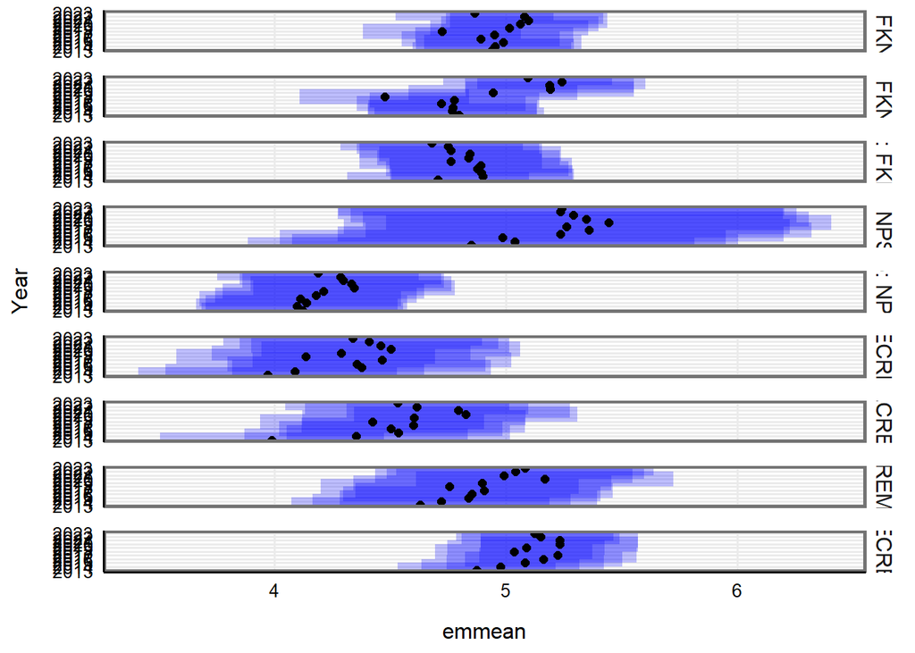

```r
plot(emm.year.hab)
```

```r
emm.hab.year <- emmeans(Best_model.ar1, ~ Reg.Hab|Year) #does the opposite, will compare habitats within years
pairs(emm.hab.year)
```

```
## Year = 2013:
##  contrast                               estimate    SE  df z.ratio p.value
##  FKNMS _ OD - FKNMS _ OS                 0.14216 0.256 Inf   0.556  0.9998
##  FKNMS _ OD - FKNMS _ P                  0.23296 0.266 Inf   0.875  0.9942
##  FKNMS _ OD - NPSDT _ OD                 0.08949 0.522 Inf   0.171  1.0000
##  FKNMS _ OD - NPSDT _ P                  0.81953 0.283 Inf   2.899  0.0888
##  FKNMS _ OD - SECREMP _ Inner            0.96958 0.335 Inf   2.896  0.0895
##  FKNMS _ OD - SECREMP _ Middle           0.95055 0.303 Inf   3.140  0.0446
##  FKNMS _ OD - SECREMP _ Nearshore        0.30948 0.334 Inf   0.928  0.9915
##  FKNMS _ OD - SECREMP _ Outer            0.06595 0.246 Inf   0.268  1.0000
##  FKNMS _ OS - FKNMS _ P                  0.09081 0.274 Inf   0.331  1.0000
##  FKNMS _ OS - NPSDT _ OD                -0.05267 0.526 Inf  -0.100  1.0000
##  FKNMS _ OS - NPSDT _ P                  0.67738 0.291 Inf   2.332  0.3229
##  FKNMS _ OS - SECREMP _ Inner            0.82742 0.341 Inf   2.423  0.2710
##  FKNMS _ OS - SECREMP _ Middle           0.80839 0.310 Inf   2.607  0.1834
##  FKNMS _ OS - SECREMP _ Nearshore        0.16732 0.340 Inf   0.492  0.9999
##  FKNMS _ OS - SECREMP _ Outer           -0.07620 0.255 Inf  -0.298  1.0000
##  FKNMS _ P - NPSDT _ OD                 -0.14348 0.531 Inf  -0.270  1.0000
##  FKNMS _ P - NPSDT _ P                   0.58657 0.300 Inf   1.957  0.5737
##  FKNMS _ P - SECREMP _ Inner             0.73661 0.349 Inf   2.109  0.4671
##  FKNMS _ P - SECREMP _ Middle            0.71758 0.319 Inf   2.251  0.3722
##  FKNMS _ P - SECREMP _ Nearshore         0.07651 0.348 Inf   0.220  1.0000
##  FKNMS _ P - SECREMP _ Outer            -0.16701 0.266 Inf  -0.628  0.9995
##  NPSDT _ OD - NPSDT _ P                  0.73005 0.540 Inf   1.352  0.9153
##  NPSDT _ OD - SECREMP _ Inner            0.88009 0.569 Inf   1.547  0.8331
##  NPSDT _ OD - SECREMP _ Middle           0.86106 0.551 Inf   1.564  0.8246
##  NPSDT _ OD - SECREMP _ Nearshore        0.21999 0.568 Inf   0.387  1.0000
##  NPSDT _ OD - SECREMP _ Outer           -0.02353 0.522 Inf  -0.045  1.0000
##  NPSDT _ P - SECREMP _ Inner             0.15004 0.362 Inf   0.414  1.0000
##  NPSDT _ P - SECREMP _ Middle            0.13101 0.333 Inf   0.394  1.0000
##  NPSDT _ P - SECREMP _ Nearshore        -0.51006 0.361 Inf  -1.413  0.8932
##  NPSDT _ P - SECREMP _ Outer            -0.75358 0.282 Inf  -2.669  0.1588
##  SECREMP _ Inner - SECREMP _ Middle     -0.01903 0.378 Inf  -0.050  1.0000
##  SECREMP _ Inner - SECREMP _ Nearshore  -0.66010 0.403 Inf  -1.638  0.7840
##  SECREMP _ Inner - SECREMP _ Outer      -0.90362 0.334 Inf  -2.702  0.1470
##  SECREMP _ Middle - SECREMP _ Nearshore -0.64107 0.377 Inf  -1.701  0.7462
##  SECREMP _ Middle - SECREMP _ Outer     -0.88459 0.302 Inf  -2.925  0.0828
##  SECREMP _ Nearshore - SECREMP _ Outer  -0.24352 0.333 Inf  -0.731  0.9984
##
## Year = 2014:
```

[output cut: 376 more lines]

```
##  NPSDT _ OD - SECREMP _ Nearshore        0.15771 0.567 Inf   0.278  1.0000
##  NPSDT _ OD - SECREMP _ Outer            0.11527 0.521 Inf   0.221  1.0000
##  NPSDT _ P - SECREMP _ Inner            -0.14896 0.361 Inf  -0.412  1.0000
##  NPSDT _ P - SECREMP _ Middle           -0.34270 0.332 Inf  -1.033  0.9828
##  NPSDT _ P - SECREMP _ Nearshore        -0.89397 0.360 Inf  -2.480  0.2414
##  NPSDT _ P - SECREMP _ Outer            -0.93641 0.282 Inf  -3.320  0.0253
##  SECREMP _ Inner - SECREMP _ Middle     -0.19374 0.377 Inf  -0.514  0.9999
##  SECREMP _ Inner - SECREMP _ Nearshore  -0.74501 0.402 Inf  -1.853  0.6464
##  SECREMP _ Inner - SECREMP _ Outer      -0.78745 0.334 Inf  -2.360  0.3063
##  SECREMP _ Middle - SECREMP _ Nearshore -0.55127 0.376 Inf  -1.467  0.8710
##  SECREMP _ Middle - SECREMP _ Outer     -0.59371 0.301 Inf  -1.969  0.5651
##  SECREMP _ Nearshore - SECREMP _ Outer  -0.04244 0.333 Inf  -0.128  1.0000
##
## Results are given on the log (not the response) scale.
## P value adjustment: tukey method for comparing a family of 9 estimates
```

```r
contrast(emm.hab.year)
```

```
## Year = 2013:
##  contrast                   estimate    SE  df z.ratio p.value
##  FKNMS _ OD effect            0.3977 0.178 Inf   2.233  0.0975
##  FKNMS _ OS effect            0.2556 0.188 Inf   1.362  0.2599
##  FKNMS _ P effect             0.1648 0.199 Inf   0.830  0.5230
##  NPSDT _ OD effect            0.3083 0.443 Inf   0.696  0.5474
##  NPSDT _ P effect            -0.4218 0.216 Inf  -1.956  0.1113
##  SECREMP _ Inner effect      -0.5718 0.267 Inf  -2.138  0.0975
##  SECREMP _ Middle effect     -0.5528 0.236 Inf  -2.344  0.0975
##  SECREMP _ Nearshore effect   0.0883 0.266 Inf   0.331  0.7403
##  SECREMP _ Outer effect       0.3318 0.178 Inf   1.867  0.1113
##
## Year = 2014:
##  contrast                   estimate    SE  df z.ratio p.value
##  FKNMS _ OD effect            0.2975 0.178 Inf   1.676  0.2111
##  FKNMS _ OS effect            0.1120 0.187 Inf   0.599  0.6180
##  FKNMS _ P effect             0.2444 0.198 Inf   1.231  0.3273
##  NPSDT _ OD effect            0.3838 0.443 Inf   0.867  0.4962
##  NPSDT _ P effect            -0.5573 0.216 Inf  -2.586  0.0875
##  SECREMP _ Inner effect      -0.5660 0.267 Inf  -2.119  0.1534
##  SECREMP _ Middle effect     -0.3018 0.235 Inf  -1.283  0.3273
##  SECREMP _ Nearshore effect   0.0660 0.266 Inf   0.248  0.8043
##  SECREMP _ Outer effect       0.3214 0.178 Inf   1.810  0.2109
##
## Year = 2015:
##  contrast                   estimate    SE  df z.ratio p.value
##  FKNMS _ OD effect            0.2525 0.178 Inf   1.423  0.4051
##  FKNMS _ OS effect            0.0366 0.187 Inf   0.196  0.8448
##  FKNMS _ P effect             0.1603 0.198 Inf   0.808  0.6287
##  NPSDT _ OD effect            0.2521 0.443 Inf   0.569  0.7318
##  NPSDT _ P effect            -0.5967 0.215 Inf  -2.770  0.0505
##  SECREMP _ Inner effect      -0.3574 0.267 Inf  -1.341  0.4051
##  SECREMP _ Middle effect     -0.1994 0.235 Inf  -0.849  0.6287
##  SECREMP _ Nearshore effect   0.1032 0.266 Inf   0.388  0.7853
##  SECREMP _ Outer effect       0.3487 0.177 Inf   1.965  0.2225
##
## Year = 2016:
##  contrast                   estimate    SE  df z.ratio p.value
##  FKNMS _ OD effect            0.1463 0.178 Inf   0.824  0.6148
##  FKNMS _ OS effect           -0.0251 0.187 Inf  -0.134  0.8931
```

[output cut: 79 more lines]

```
##
## Year = 2023:
##  contrast                   estimate    SE  df z.ratio p.value
##  FKNMS _ OD effect            0.0710 0.178 Inf   0.399  0.6895
##  FKNMS _ OS effect            0.3007 0.187 Inf   1.610  0.2417
##  FKNMS _ P effect            -0.1150 0.199 Inf  -0.579  0.6329
##  NPSDT _ OD effect            0.4466 0.442 Inf   1.009  0.4021
##  NPSDT _ P effect            -0.6051 0.215 Inf  -2.809  0.0448
##  SECREMP _ Inner effect      -0.4561 0.267 Inf  -1.710  0.2417
##  SECREMP _ Middle effect     -0.2624 0.235 Inf  -1.116  0.4021
##  SECREMP _ Nearshore effect   0.2889 0.266 Inf   1.087  0.4021
##  SECREMP _ Outer effect       0.3313 0.177 Inf   1.867  0.2417
##
## Results are given on the log (not the response) scale.
## P value adjustment: fdr method for 9 tests
```

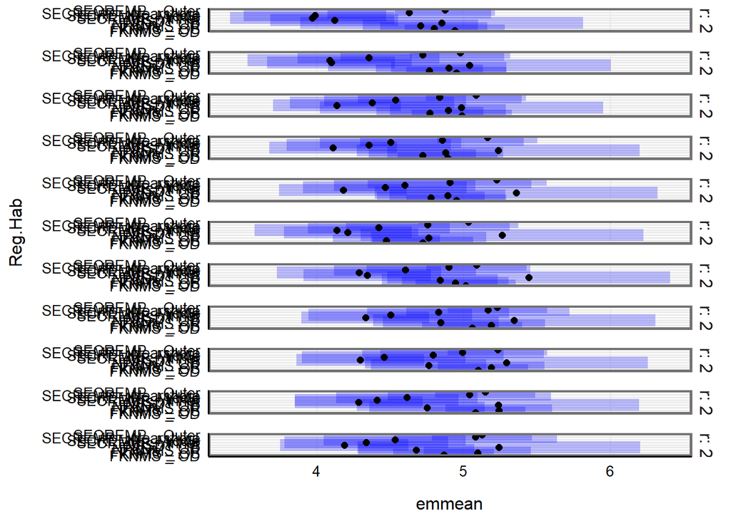

```r
plot(emm.hab.year)
```

```r
### for completeness I've included the marginal emmeans for each fixed factor

emm.hab <- emmeans(Best_model.ar1, ~ Reg.Hab)
```

```
## NOTE: Results may be misleading due to involvement in interactions
```

```r
pairs(emm.hab)
```

```
##  contrast                               estimate    SE  df z.ratio p.value
##  FKNMS _ OD - FKNMS _ OS                 0.05436 0.248 Inf   0.219  1.0000
##  FKNMS _ OD - FKNMS _ P                  0.15044 0.259 Inf   0.580  0.9997
##  FKNMS _ OD - NPSDT _ OD                -0.24785 0.509 Inf  -0.487  0.9999
##  FKNMS _ OD - NPSDT _ P                  0.75081 0.274 Inf   2.736  0.1352
##  FKNMS _ OD - SECREMP _ Inner            0.65242 0.325 Inf   2.007  0.5381
##  FKNMS _ OD - SECREMP _ Middle           0.43562 0.294 Inf   1.482  0.8643
##  FKNMS _ OD - SECREMP _ Nearshore        0.06178 0.325 Inf   0.190  1.0000
##  FKNMS _ OD - SECREMP _ Outer           -0.14693 0.240 Inf  -0.612  0.9996
##  FKNMS _ OS - FKNMS _ P                  0.09608 0.267 Inf   0.360  1.0000
##  FKNMS _ OS - NPSDT _ OD                -0.30220 0.513 Inf  -0.589  0.9997
##  FKNMS _ OS - NPSDT _ P                  0.69646 0.282 Inf   2.471  0.2459
##  FKNMS _ OS - SECREMP _ Inner            0.59806 0.331 Inf   1.805  0.6788
##  FKNMS _ OS - SECREMP _ Middle           0.38126 0.301 Inf   1.267  0.9408
##  FKNMS _ OS - SECREMP _ Nearshore        0.00743 0.331 Inf   0.022  1.0000
##  FKNMS _ OS - SECREMP _ Outer           -0.20128 0.248 Inf  -0.810  0.9966
##  FKNMS _ P - NPSDT _ OD                 -0.39829 0.518 Inf  -0.768  0.9977
##  FKNMS _ P - NPSDT _ P                   0.60037 0.291 Inf   2.061  0.5007
##  FKNMS _ P - SECREMP _ Inner             0.50198 0.339 Inf   1.479  0.8657
##  FKNMS _ P - SECREMP _ Middle            0.28518 0.310 Inf   0.920  0.9919
##  FKNMS _ P - SECREMP _ Nearshore        -0.08866 0.339 Inf  -0.261  1.0000
##  FKNMS _ P - SECREMP _ Outer            -0.29737 0.259 Inf  -1.147  0.9669
##  NPSDT _ OD - NPSDT _ P                  0.99866 0.526 Inf   1.898  0.6150
##  NPSDT _ OD - SECREMP _ Inner            0.90027 0.554 Inf   1.624  0.7916
##  NPSDT _ OD - SECREMP _ Middle           0.68347 0.537 Inf   1.274  0.9390
##  NPSDT _ OD - SECREMP _ Nearshore        0.30963 0.554 Inf   0.559  0.9998
##  NPSDT _ OD - SECREMP _ Outer            0.10092 0.509 Inf   0.198  1.0000
##  NPSDT _ P - SECREMP _ Inner            -0.09839 0.351 Inf  -0.280  1.0000
##  NPSDT _ P - SECREMP _ Middle           -0.31519 0.323 Inf  -0.977  0.9880
##  NPSDT _ P - SECREMP _ Nearshore        -0.68903 0.351 Inf  -1.962  0.5699
##  NPSDT _ P - SECREMP _ Outer            -0.89774 0.274 Inf  -3.272  0.0296
##  SECREMP _ Inner - SECREMP _ Middle     -0.21680 0.367 Inf  -0.591  0.9997
##  SECREMP _ Inner - SECREMP _ Nearshore  -0.59064 0.392 Inf  -1.507  0.8527
##  SECREMP _ Inner - SECREMP _ Outer      -0.79935 0.325 Inf  -2.460  0.2520
##  SECREMP _ Middle - SECREMP _ Nearshore -0.37384 0.367 Inf  -1.020  0.9841
##  SECREMP _ Middle - SECREMP _ Outer     -0.58255 0.294 Inf  -1.982  0.5561
##  SECREMP _ Nearshore - SECREMP _ Outer  -0.20871 0.325 Inf  -0.642  0.9994
##
## Results are averaged over the levels of: Year
## Results are given on the log (not the response) scale.
## P value adjustment: tukey method for comparing a family of 9 estimates
```

```r
contrast(emm.hab) #all pretty similar
```

```
##  contrast                   estimate    SE  df z.ratio p.value
##  FKNMS _ OD effect            0.1901 0.173 Inf   1.097  0.4663
##  FKNMS _ OS effect            0.1357 0.182 Inf   0.745  0.5869
##  FKNMS _ P effect             0.0396 0.194 Inf   0.205  0.8378
##  NPSDT _ OD effect            0.4379 0.432 Inf   1.013  0.4663
##  NPSDT _ P effect            -0.5607 0.209 Inf  -2.680  0.0663
##  SECREMP _ Inner effect      -0.4623 0.260 Inf  -1.781  0.2246
##  SECREMP _ Middle effect     -0.2455 0.229 Inf  -1.072  0.4663
##  SECREMP _ Nearshore effect   0.1283 0.259 Inf   0.494  0.6986
##  SECREMP _ Outer effect       0.3370 0.173 Inf   1.945  0.2246
##
## Results are averaged over the levels of: Year
## Results are given on the log (not the response) scale.
## P value adjustment: fdr method for 9 tests
```

```r
emm.year <- emmeans(Best_model.ar1, ~ Year)
```

```
## NOTE: Results may be misleading due to involvement in interactions
```

```r
pairs(emm.year)
```

```
##  contrast            estimate     SE  df z.ratio p.value
##  Year2013 - Year2014  -0.1126 0.0228 Inf  -4.934  <.0001
##  Year2013 - Year2015  -0.1922 0.0257 Inf  -7.472  <.0001
##  Year2013 - Year2016  -0.2033 0.0282 Inf  -7.217  <.0001
##  Year2013 - Year2017  -0.2745 0.0303 Inf  -9.067  <.0001
##  Year2013 - Year2018  -0.1001 0.0323 Inf  -3.100  0.0712
##  Year2013 - Year2019  -0.2865 0.0338 Inf  -8.487  <.0001
##  Year2013 - Year2020  -0.4022 0.0352 Inf -11.442  <.0001
##  Year2013 - Year2021  -0.3589 0.0365 Inf  -9.828  <.0001
##  Year2013 - Year2022  -0.3249 0.0378 Inf  -8.606  <.0001
##  Year2013 - Year2023  -0.2511 0.0389 Inf  -6.456  <.0001
##  Year2014 - Year2015  -0.0795 0.0222 Inf  -3.575  0.0155
##  Year2014 - Year2016  -0.0906 0.0252 Inf  -3.589  0.0147
##  Year2014 - Year2017  -0.1618 0.0278 Inf  -5.830  <.0001
##  Year2014 - Year2018   0.0126 0.0301 Inf   0.418  1.0000
##  Year2014 - Year2019  -0.1739 0.0318 Inf  -5.470  <.0001
##  Year2014 - Year2020  -0.2895 0.0334 Inf  -8.676  <.0001
##  Year2014 - Year2021  -0.2463 0.0349 Inf  -7.056  <.0001
##  Year2014 - Year2022  -0.2123 0.0363 Inf  -5.851  <.0001
##  Year2014 - Year2023  -0.1385 0.0375 Inf  -3.688  0.0103
##  Year2015 - Year2016  -0.0111 0.0220 Inf  -0.503  1.0000
##  Year2015 - Year2017  -0.0823 0.0251 Inf  -3.283  0.0409
##  Year2015 - Year2018   0.0921 0.0278 Inf   3.314  0.0372
##  Year2015 - Year2019  -0.0943 0.0298 Inf  -3.169  0.0582
##  Year2015 - Year2020  -0.2100 0.0316 Inf  -6.649  <.0001
##  Year2015 - Year2021  -0.1668 0.0333 Inf  -5.006  <.0001
##  Year2015 - Year2022  -0.1328 0.0349 Inf  -3.809  0.0065
##  Year2015 - Year2023  -0.0589 0.0363 Inf  -1.625  0.8719
##  Year2016 - Year2017  -0.0712 0.0219 Inf  -3.256  0.0445
##  Year2016 - Year2018   0.1032 0.0252 Inf   4.100  0.0020
##  Year2016 - Year2019  -0.0832 0.0275 Inf  -3.026  0.0876
##  Year2016 - Year2020  -0.1989 0.0296 Inf  -6.718  <.0001
##  Year2016 - Year2021  -0.1557 0.0316 Inf  -4.931  <.0001
##  Year2016 - Year2022  -0.1217 0.0333 Inf  -3.653  0.0117
##  Year2016 - Year2023  -0.0478 0.0349 Inf  -1.372  0.9552
##  Year2017 - Year2018   0.1744 0.0220 Inf   7.926  <.0001
##  Year2017 - Year2019  -0.0120 0.0249 Inf  -0.483  1.0000
##  Year2017 - Year2020  -0.1277 0.0274 Inf  -4.669  0.0002
##  Year2017 - Year2021  -0.0845 0.0296 Inf  -2.852  0.1388
##  Year2017 - Year2022  -0.0504 0.0316 Inf  -1.597  0.8839
##  Year2017 - Year2023   0.0234 0.0333 Inf   0.702  0.9998
##  Year2018 - Year2019  -0.1864 0.0219 Inf  -8.502  <.0001
##  Year2018 - Year2020  -0.3021 0.0249 Inf -12.120  <.0001
##  Year2018 - Year2021  -0.2589 0.0276 Inf  -9.391  <.0001
##  Year2018 - Year2022  -0.2249 0.0298 Inf  -7.543  <.0001
##  Year2018 - Year2023  -0.1510 0.0318 Inf  -4.751  0.0001
##  Year2019 - Year2020  -0.1157 0.0215 Inf  -5.374  <.0001
##  Year2019 - Year2021  -0.0725 0.0247 Inf  -2.928  0.1143
##  Year2019 - Year2022  -0.0384 0.0274 Inf  -1.403  0.9481
##  Year2019 - Year2023   0.0354 0.0297 Inf   1.193  0.9834
##  Year2020 - Year2021   0.0432 0.0215 Inf   2.013  0.6396
##  Year2020 - Year2022   0.0772 0.0247 Inf   3.129  0.0654
##  Year2020 - Year2023   0.1511 0.0274 Inf   5.519  <.0001
##  Year2021 - Year2022   0.0340 0.0216 Inf   1.575  0.8931
##  Year2021 - Year2023   0.1079 0.0248 Inf   4.343  0.0007
##  Year2022 - Year2023   0.0738 0.0218 Inf   3.395  0.0286
##
## Results are averaged over the levels of: Reg.Hab
## Results are given on the log (not the response) scale.
## P value adjustment: tukey method for comparing a family of 11 estimates
```

```r
contrast(emm.year)
```

```
##  contrast        estimate     SE  df z.ratio p.value
##  Year2013 effect  -0.2278 0.0238 Inf  -9.556  <.0001
##  Year2014 effect  -0.1152 0.0215 Inf  -5.367  <.0001
##  Year2015 effect  -0.0357 0.0196 Inf  -1.818  0.0845
##  Year2016 effect  -0.0246 0.0182 Inf  -1.349  0.1951
##  Year2017 effect   0.0466 0.0173 Inf   2.692  0.0098
##  Year2018 effect  -0.1278 0.0172 Inf  -7.411  <.0001
##  Year2019 effect   0.0587 0.0172 Inf   3.401  0.0011
##  Year2020 effect   0.1743 0.0180 Inf   9.708  <.0001
##  Year2021 effect   0.1311 0.0194 Inf   6.770  <.0001
##  Year2022 effect   0.0971 0.0212 Inf   4.589  <.0001
##  Year2023 effect   0.0232 0.0233 Inf   0.998  0.3182
##
## Results are averaged over the levels of: Reg.Hab
## Results are given on the log (not the response) scale.
## P value adjustment: fdr method for 11 tests
```

### NJ - you don’t need the next steps